# bayesianI

## 1 Description

### Course STAT565 Decision Theory and Bayesian Analysis

#### Semester Fall 2017

#### Content Conjugate priors of single parameter models and triplot representations

#### Author Enes Dilber

Most notes taken from http://www.stat.columbia.edu/~gelman/book/

# 2 Conjugacy

## 2.1 Beta-Binomial

Suppose we have sum of trials with two outcomes and do not have a prior knowledge about success probability. Our experiment clearly represented by Binomial distribution and we can use $Uniform(0,1)$ for our prior knowledge. Because we have equal probability for success probability. However we use $Beta(1,1)$ instead of $Uniform(0,1)$. Actually, the thing is when the parameters of Beta $\theta = (\alpha = 1, \beta = 1)$, it becomes $Uniform(0,1)$.

$$L(y|\theta) \propto \theta^y (1-\theta)^{n-y} \tag{1}$$
$$P(\theta) \propto \theta^{\alpha_0-1} (1-\theta)^{\beta_0-1} \tag{2}$$
$$P(\theta|y) \propto \theta^{y+ \alpha_0-1} (1-\theta)^{n-y+\beta_0-1} \tag{3}$$
Hence;

$$ \theta|y \sim Beta(\alpha = y + \alpha_0, \beta = n-y+\beta_0) \tag{4} $$

So if we do not have any prior information about theta, we would chose $\alpha_0 = \beta_0 = 1$. In this case. Posterior distribution would be $Beta(\alpha = y+1, \beta = n-y+1)$. So expectation of posterior = $\frac{\alpha}{\alpha+\beta} = \frac{y+1}{n+2}$

### 2.1.1 Triplot

A triplot is a visulazation method to show the affects of prior and likelihood on posterior.

### Ex1

```r
#Let's write R functions for Prior, Posterior and Likelihood

Lik_binom = function(n, y){

    #n = trials
    #y = successes

    const = integrate(function(x) (x^y)*(1-x)^(n-y), 0, 1)$value #denominator that makes AUC of Likelihood 1.

    function(theta){

        ((theta^y)*(1-theta)^(n-y))/const

    }
}

Prior_beta = function(a0, b0){

    #a0 = shape 1
    #b0 = shape 2

    function(theta){

        dbeta(theta, a0, b0)

        }
}

Post_beta = function(a0, b0, n, y){

    function(theta){

        dbeta(theta, y + a0 , n - y + b0 )

        }
}
```

```r
triplot = function(a0, b0, n, y){

    Lik_binom_fixed = Vectorize(Lik_binom(n, y))
    Prior_beta_fixed = Vectorize(Prior_beta(a0, b0))
    Post_beta_fixed = Vectorize(Post_beta(a0, b0, n, y))

    N = 1000
    theta_seq = seq(0, 1, length = N)

    Lik_Vals = Lik_binom_fixed(theta_seq)
    Pri_Vals = Prior_beta_fixed(theta_seq)
    Pos_Vals = Post_beta_fixed(theta_seq)

    mydf = data.frame(Theta = rep(theta_seq, 3),
                      Distribution = rep(c("Likelihood", "Prior", "Posterior"), each = N),
                      Values = c(Lik_Vals, Pri_Vals, Pos_Vals))




    print(paste("Prior: Beta(", a0, b0,")"))
    print(paste("Likelihood: Likelihood of Binomial Theta with ", y, "successes in ", n," trials"))
    print(paste("Posterior: Beta(", y + a0 , n - y + b0 ,")"))

    library(ggplot2)

    ggplot(data=mydf, aes(x=Theta, y=Values)) +
      geom_line(aes(color=Distribution), size = 2)

}
```

```
[1] "Prior: Beta( 4 4 )"
[1] "Likelihood: Likelihood of Binomial Theta with  6 successes in  15  trials"
[1] "Posterior: Beta( 10 13 )"
```

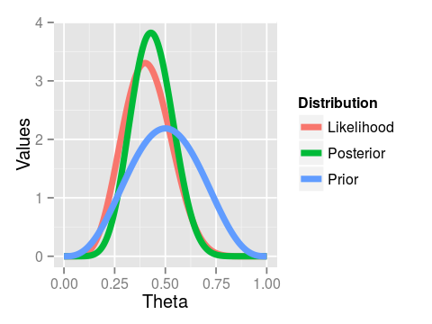

```r
a0 = 4 ; b0 = 4 #E(theta) = 1/2

set.seed(1)
n = 15
y = rbinom(1, n, 0.5)

triplot(a0, b0, n, y)
```

### Sequential Update:

Now he is going to bet again. But before the bet, he is going to experiment the coin again. This time he is going to experiment it 5 times and he will use the his earlier knowledge, that is the posterior distribution. And then repeat this with n = 100.

```
[1] "Prior: Beta( 10 13 )"
[1] "Likelihood: Likelihood of Binomial Theta with  2 successes in  5  trials"
[1] "Posterior: Beta( 12 16 )"
```

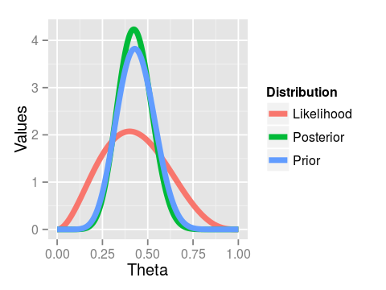

```r
a0 = 10 ; b0 = 13 #E(theta) = 10/26

set.seed(1)
n = 5
y = rbinom(1, n, 0.5)

triplot(a0, b0, n, y)
```

```
[1] "Prior: Beta( 12 16 )"
[1] "Likelihood: Likelihood of Binomial Theta with  52 successes in  100  trials"
[1] "Posterior: Beta( 64 64 )"
```

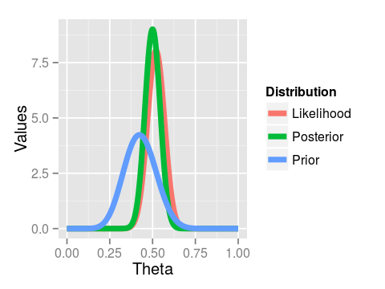

```r
a0 = 12 ; b0 = 16 #E(theta) = 12/28

set.seed(1)
n = 100
y = rbinom(1, n, 0.5)

triplot(a0, b0, n, y)
```

One can see that, If the sample size of likelihood is large, it dominates the posterior. Otherwise, posterior is dramatically affected by prior belief.

## 2.2 Normal-Normal

Let $y=(y_1,...,y_n) \ iid \ \sim N(\mu, \sigma^2)$ where $\sigma^2$ is known. Assume we want to estimate $\mu$. Our prior belief is $\mu \sim N(m, v)$. What is our posterior?

$$L(y|\mu) \propto exp \biggl(-\frac{1}{2}\sigma^{-2} n(\bar{x}-\mu)^2 \biggr) \tag{1}$$
$$P(\mu) \propto exp \biggl(-\frac{1}{2} v^{-1} (\mu-m)^2 \biggr) \tag{2}$$

This time finding posterior will be a little trickier. However we know it is going to be a normal distribution. By the light of this knowledge we could easiliy find $v^*$ and $m^*$

$$P(\mu | y) \propto exp \biggl(-\frac{1}{2} \biggl( v^{-1} (\mu-m)^2 + \sigma^{-2} n(\bar{x}-\mu)^2 \biggr) \biggr) \tag{3}$$

Lets say;

$$P(\mu | y) \propto exp \biggl(-\frac{1}{2} h(\mu;m,v,\sigma^2,\bar{x}) \biggr) \tag{4}$$

If it is a normal distribution, then the form of $h$ should be like this;

$$ \biggl( \frac{\mu - m^*}{v^*} \biggr)^2 \tag{5}$$

$$P(\mu | y) \propto exp \biggl(-\frac{1}{2} \bigl( v^{-1} (\mu^2-2m \mu +m^2) + \sigma^{-2} n(\bar{x}^2-2\bar{x}\mu+\mu^2 ) \bigr) \biggr) \tag{6}$$

$$P(\mu | y) \propto exp \biggl(-\frac{1}{2} \bigl( \mu^2(v^{-1}+n\sigma^{-2})- 2 \mu(n\sigma^{-2}\bar{x}+v^{-1}m)+r \bigr) \biggr) \tag{7}$$

By just obtaining coefficients of $\mu$ and $\mu^2$ we could write $h(\mu;m,v,\sigma^2,\bar{x})$, because as we said, it is normal.

### 2.2.1 Triplot

This triplot is more straightforward than beta-binomial. All 3 distributions are normal.

```r
triplot = function(m, v, X, sigma2){

    xbar = mean(X)
    n = length(X)
    xvar = var(X)

    const = integrate(function(Mu) exp((-0.5*sigma2^-1)*n*(xbar-Mu)^2), -Inf, Inf)$value

    vS = (v^-1+n*sigma2^-1)^(-1)
    mS = (n*xbar*sigma2^-1+m*v^-1)*vS

    N = 1000
    Mu_seq = seq(mS-5*vS, mS+5*vS, length = N)

    Lik_Vals = exp((-0.5*sigma2^-1)*n*(xbar-Mu_seq)^2)/const
    Pri_Vals = dnorm(Mu_seq, m, sqrt(v))
    Pos_Vals = dnorm(Mu_seq, mS, sqrt(vS))

    mydf = data.frame(Mu = rep(Mu_seq, 3),
                      Distribution = rep(c("Likelihood", "Prior", "Posterior"), each = N),
                      Values = c(Lik_Vals, Pri_Vals, Pos_Vals))

    print(paste("Prior: Normal(", m, v,")"))
    print(paste("Likelihood: Likelihood of Normal Mu with xbar", xbar, "and sample variance ",xvar))
    print(paste("Posterior:  Normal(", mS, vS,")"))

    library(ggplot2)

    ggplot(data=mydf, aes(x=Mu, y=Values)) +
      geom_line(aes(color=Distribution), size = 2)

}
```

### Ex2

```
[1] "Prior: Normal( 2 2 )"
[1] "Likelihood: Likelihood of Normal Mu with xbar 5.08539790009142 and sample variance  369.438710598692"
[1] "Posterior:  Normal( 3.02846596669714 1.33333333333333 )"
```

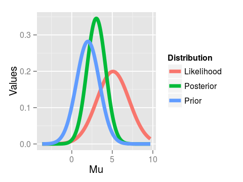

```r
n=5
m=2
v=2
set.seed(1)
sigma2 = 20
X = rnorm(n, 2.5, sigma2)
triplot(m, v, X, sigma2)
```

```
[1] "Prior: Normal( 2 2 )"
[1] "Likelihood: Likelihood of Normal Mu with xbar 4.51685689099435 and sample variance  414.280901941411"
[1] "Posterior:  Normal( 3.51011413459661 0.8 )"
```

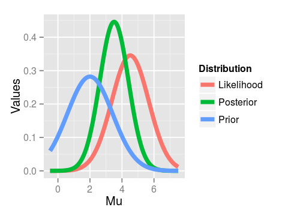

```r
n=15
m=2
v=2
set.seed(1)
sigma2 = 20
X = rnorm(n, 2.5, sigma2)
triplot(m, v, X, sigma2)
```

```
[1] "Prior: Normal( 2 2 )"
[1] "Likelihood: Likelihood of Normal Mu with xbar 2.93526196066107 and sample variance  327.016536633006"
[1] "Posterior:  Normal( 2.87680808811975 0.125 )"
```

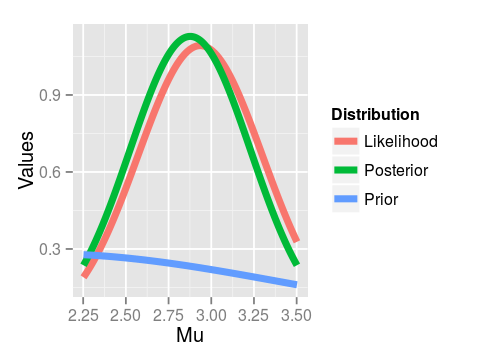

```r
n=150
m=2
v=2
set.seed(1)
sigma2 = 20
X = rnorm(n, 2.5, sigma2)
triplot(m, v, X, sigma2)
```